# Plots_and_Analyses.R

### Plotting risk

Now generate a simple forest plot of these associations for each of the models

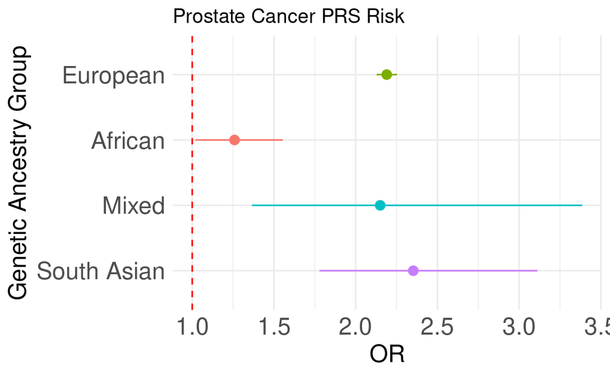

```r
# For PRS451
summ_df %>% filter(PRS == "PRS_451") %>%
  # Define the space and plot area
  ggplot() +
  theme_minimal()+
  # Place the ORs and vline
  geom_pointrange(aes(x = OR, y = ancestry, xmin = low95, xmax = up95, colour = ancestry),
                  show.legend = F,
                  position = position_dodge(width = 1)) +
  geom_vline(xintercept = 1, linetype = "dashed", color = "red") +

  # Final labels
  labs(x = "OR", y = "Genetic Ancestry Group") +
  scale_y_discrete(labels = c("mix" = "Mixed",
                              "sas" = "South Asian",
                              "afr" = "African",
                              "eur" = "European"),
                   limits = c("sas","mix","afr","eur")
                   ) +
  ggtitle("Prostate Cancer PRS Risk") +
  theme(axis.title = element_text(size = 16),
        axis.text = element_text(size = 16))
```

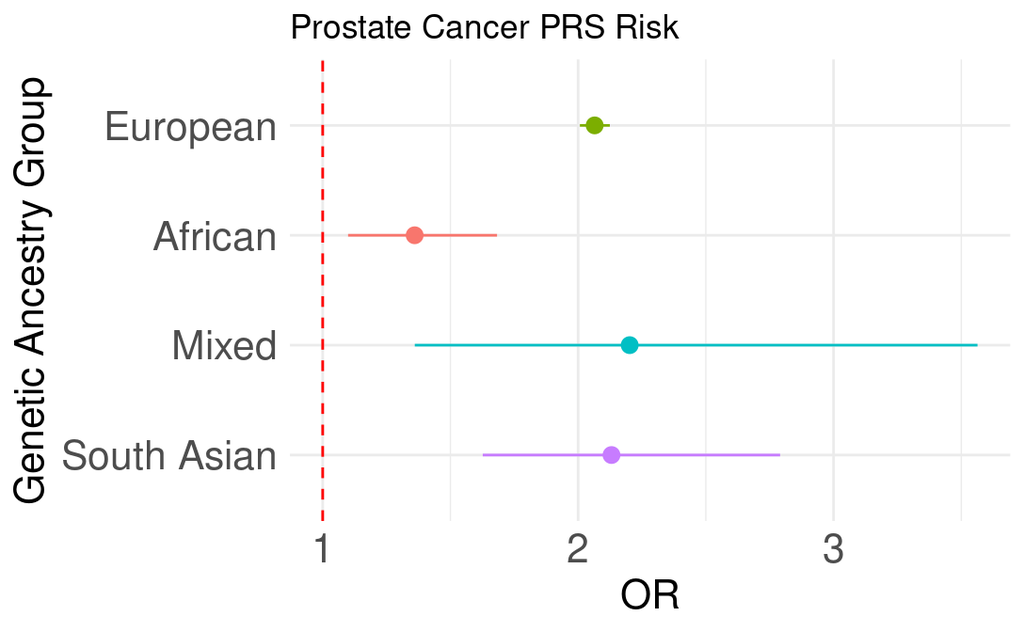

```r
# For PRS269
summ_df %>% filter(PRS == "PRS_269") %>%
  # Define the space and plot area
  ggplot() +
  theme_minimal()+
  # Place the ORs and vline
  geom_pointrange(aes(x = OR, y = ancestry, xmin = low95, xmax = up95, colour = ancestry),
                  show.legend = F,
                  position = position_dodge(width = 1)) +
  geom_vline(xintercept = 1, linetype = "dashed", color = "red") +

  # Final labels
  labs(x = "OR", y = "Genetic Ancestry Group") +
  scale_y_discrete(labels = c("mix" = "Mixed",
                              "sas" = "South Asian",
                              "afr" = "African",
                              "eur" = "European"),
                   limits = c("sas","mix","afr","eur")
                   ) +
  ggtitle("Prostate Cancer PRS Risk") +
  theme(axis.title = element_text(size = 16),
        axis.text = element_text(size = 16))
```

[figure not shown]

```r
# For PRScsx
summ_df %>% filter(PRS == "PRS_csx") %>%
  # Define the space and plot area
  ggplot() +
  theme_minimal()+
  # Place the ORs and vline
  geom_pointrange(aes(x = OR, y = ancestry, xmin = low95, xmax = up95, colour = ancestry),
                  show.legend = F,
                  position = position_dodge(width = 1)) +
  geom_vline(xintercept = 1, linetype = "dashed", color = "red") +

  # Final labels
  labs(x = "OR", y = "Genetic Ancestry Group") +
  scale_y_discrete(labels = c("mix" = "Mixed",
                              "sas" = "South Asian",
                              "afr" = "African",
                              "eur" = "European"),
                   limits = c("sas","mix","afr","eur")
                   ) +
  ggtitle("Prostate Cancer PRS Risk") +
  theme(axis.title = element_text(size = 16),
        axis.text = element_text(size = 16))
```

```r
NA
NA
```

## Supp 2 - Simple interaction

In order to take advantage of non-European data, I will run simple nSES*PRS logistic regression models to see the non-sig interactions across ancestries

```r
keep_variables = c("data_df", "keep_variables", "ses_factors", "ances")
rm(list = ls()[!(ls() %in% keep_variables)])

# Create some dataframes to save the prevalence per ancestry
summ_df = tibble()

# I also want to loop through this per ancestry
for (j in ances){

  # Print ancestry to benchmark
  print(j)

  # Let's pull out the ancestry specific data and set list for models for this ancestry
  data_split = data_df %>% filter(Ances == j)
  model_results = list()

  # Now create a loop that models the variables of interest and then saves them to a list of models
  # Each loop will run a model for total, incidence, and prevalent cases
  for (i in ses_factors){


    # Create symbol for coding reason
    i = sym(i)

    # Calculate the standardized data for the Deprivation index of interest
      temp_df = data_split %>% drop_na(!!i) %>%
        mutate(Deprivation_z = scale(!!i)[,1]
               )

    # Run models of interest
      formula = paste0("prostate_incident ~ Deprivation_z + PRS_z + Deprivation_z*PRS_z",
                   " + age_assessment", str_flatten(str_c("+ PC",1:10))
                   ) %>% as.formula()

      model = logistic_reg() %>% fit(formula, data = temp_df)

      OR = tidy(model, exponentiate = T) %>%
        rename(OR = estimate) %>%
        mutate(low95 = exp(log(OR) - 1.96*std.error),
               up95 = exp(log(OR) + 1.96*std.error),
               p.value = (mpfr(statistic, precBits = 256) %>%
                        pnorm(., lower.tail = FALSE) %>%
                        as.numeric(2*.))
               ) %>%
        select(-std.error, -statistic)

      # Pull specific results before saving
      model_results[[i]] <- OR[c(2,3,15),]


    # Benchmark that this set of model is complete
    print(i)
  }

  # Save the models
  results_df = list_rbind(model_results, names_to = "ses")

  # Remove the term variable (since it's redundant) and then add to summary data_frame
  summ_df = results_df %>%
    mutate(ancestry = j) %>%
    rbind(summ_df, .)

}
```

```
[1] "eur"
IMD
Income
Employment
Health
Education
Housing
Crime
Environment
Townsend
[1] "afr"
IMD
Income
Employment
Health
Education
Housing
Crime
Environment
Townsend
```

```r
# And now export these models.
summ_df %>%
  write_csv( file = "/labs/jswitte/Projects/jjudd5/SES.PRS_Project/Supp_Figures/Supp2_models_2024.07.02.csv")
```

## Supp 3 - Sensitivity Analyses (PSA Screening & Healthcare Utilization)

I will use this next section to start incorporating some of the models/questions I have about PSA Screening and healthcare utilization. I will specificially make 4 sets of models - PCa ~ nSES + PSA Screening - PCa ~ nSES + Healthcare Utilization - PCA ~ nSES + PSA + Healthcare - corr(PSA Screening, Healthcare Utilization, nSES)

### PCa ~ nSES + PSA Screening

I want to include PSA Screening as a covariate in my nSES to see how the effect changes

```r
keep_variables = c("data_df", "keep_variables", "ses_factors", "ances")
rm(list = ls()[!(ls() %in% keep_variables)])

# Create some dataframes to save the prevalence per ancestry
summ_df = tibble() # For nSES effects

# I also want to loop through this per ancestry
for (j in ances){

  # Print ancestry to benchmark
  print(j)

  # Let's pull out the ancestry specific data and set list for models for this ancestry
  data_split = data_df %>% filter(Ances == j)
  model_results = list() # This is for the nSES effects

  # Now create a loop that models the variables of interest and then saves them to a list of models
  # Each loop will run a model for total, incidence, and prevalent cases
  for (i in ses_factors){


    # Create symbol for coding reason
    i = sym(i)

    # Calculate the standardized data for the Deprivation index of interest
      temp_df = data_split %>% drop_na(!!i) %>%
        mutate(Deprivation_z = scale(!!i)[,1]
               )

    # Run models of interest
      formula = paste0("prostate_incident ~ Deprivation_z + age_assessment + PSA_Screening"
                       ) %>% as.formula()

      model = logistic_reg() %>% fit(formula, data = temp_df)

      OR = tidy(model, exponentiate = T) %>%
        rename(OR = estimate) %>%
        mutate(low95 = exp(log(OR) - 1.96*std.error),
               up95 = exp(log(OR) + 1.96*std.error)) %>%
        select(-std.error, -statistic)

      # Pull specific results before saving
      model_results[[i]] <- OR[c(2,4),]

    # Benchmark that this set of model is complete
    print(i)
  }


  # Save the models
  results_df = list_rbind(model_results, names_to = "ses")

  # Remove the term variable (since it's redundant) and then add to summary data_frame
  summ_df = results_df %>%
    mutate(ancestry = j) %>%
    rbind(summ_df, .)

}
summ_df = summ_df %>% select(ancestry, ses, everything())


# And now export these models.
summ_df %>%
  write_csv( file = "/labs/jswitte/Projects/jjudd5/SES.PRS_Project/Supp_Figures/Supp3_PCA.PSA_models_2024.05.20.csv")
```

### PCa ~ nSES + Healthcare

I also want to make the models where I include this variable as a covariate

```r
keep_variables = c("data_df", "keep_variables", "ses_factors", "ances")
rm(list = ls()[!(ls() %in% keep_variables)])

# Create some dataframes to save the prevalence per ancestry
summ_df = tibble() # For nSES effects

# I also want to loop through this per ancestry
for (j in ances){

  # Print ancestry to benchmark
  print(j)

  # Let's pull out the ancestry specific data and set list for models for this ancestry
  data_split = data_df %>% filter(Ances == j)
  model_results = list() # This is for the nSES effects

  # Now create a loop that models the variables of interest and then saves them to a list of models
  # Each loop will run a model for total, incidence, and prevalent cases
  for (i in ses_factors){


    # Create symbol for coding reason
    i = sym(i)

    # Calculate the standardized data for the Deprivation index of interest
      temp_df = data_split %>% drop_na(!!i) %>%
        mutate(Deprivation_z = scale(!!i)[,1]
               )

    # Run models of interest
      formula = paste0("prostate_incident ~ Deprivation_z + age_assessment + no_visits"
                       ) %>% as.formula()

      model = logistic_reg() %>% fit(formula, data = temp_df)

      OR = tidy(model, exponentiate = T) %>%
        rename(OR = estimate) %>%
        mutate(low95 = exp(log(OR) - 1.96*std.error),
               up95 = exp(log(OR) + 1.96*std.error)) %>%
        select(-std.error, -statistic)

      # Pull specific results before saving
      model_results[[i]] <- OR[c(2,4),]

    # Benchmark that this set of model is complete
    print(i)
  }


  # Save the models
  results_df = list_rbind(model_results, names_to = "ses")

  # Remove the term variable (since it's redundant) and then add to summary data_frame
  summ_df = results_df %>%
    mutate(ancestry = j) %>%
    rbind(summ_df, .)

}
summ_df = summ_df %>% select(ancestry, ses, everything())


# And now export these models.
summ_df %>%
  write_csv( file = "/labs/jswitte/Projects/jjudd5/SES.PRS_Project/Supp_Figures/Supp3_PCA.Visits_models_2024.05.20.csv")
```

### PCa ~ nSES + PSA + Healthcare

```r
keep_variables = c("data_df", "keep_variables", "ses_factors", "ances")
rm(list = ls()[!(ls() %in% keep_variables)])

# Create some dataframes to save the prevalence per ancestry
summ_df = tibble() # For nSES effects

# I also want to loop through this per ancestry
for (j in ances){

  # Print ancestry to benchmark
  print(j)

  # Let's pull out the ancestry specific data and set list for models for this ancestry
  data_split = data_df %>% filter(Ances == j)
  model_results = list() # This is for the nSES effects

  # Now create a loop that models the variables of interest and then saves them to a list of models
  # Each loop will run a model for total, incidence, and prevalent cases
  for (i in ses_factors){


    # Create symbol for coding reason
    i = sym(i)

    # Calculate the standardized data for the Deprivation index of interest
      temp_df = data_split %>% drop_na(!!i) %>%
        mutate(Deprivation_z = scale(!!i)[,1]
               )

    # Run models of interest
      formula = paste0("prostate_incident ~ Deprivation_z + age_assessment + PSA_Screening + no_visits"
                       ) %>% as.formula()

      model = logistic_reg() %>% fit(formula, data = temp_df)

      OR = tidy(model, exponentiate = T) %>%
        rename(OR = estimate) %>%
        mutate(low95 = exp(log(OR) - 1.96*std.error),
               up95 = exp(log(OR) + 1.96*std.error)) %>%
        select(-std.error, -statistic)

      # Pull specific results before saving
      model_results[[i]] <- OR[c(2,4,5),]

    # Benchmark that this set of model is complete
    print(i)
  }


  # Save the models
  results_df = list_rbind(model_results, names_to = "ses")

  # Remove the term variable (since it's redundant) and then add to summary data_frame
  summ_df = results_df %>%
    mutate(ancestry = j) %>%
    rbind(summ_df, .)

}
summ_df = summ_df %>% select(ancestry, ses, everything())


# And now export these models.
summ_df %>%
  write_csv( file = "/labs/jswitte/Projects/jjudd5/SES.PRS_Project/Supp_Figures/Supp3_PCA.PSA.Visits_models_2024.05.20.csv")
```